# The Effect of Severe Weather on the Public Health and Economies of Communities in the United States

## Synopsis

Presented here is a distillation of data from the U.S. National Oceanic and Atmoshperic Administration on the effect severe wheather has on population health and the economy. To determine the overall effect of population health the number of fatalities and injuries is considered. The amount of property damage and crop damage will be used to determine the effect of the weather on the economy. Since the data was collected by many different people there are not consistent identifiers for the types of weather events, ie ‘TORNADOS’ vs ‘TORNADO’. A clustering method based on the distance between event names was used to group events together. It was determined that tornados by far cause the greatest harm to public health when considering either injury or death. Droughts casue more damage to crops than any other weather event while flooding tends to cause the most property damage as well as the second most damage to crops.

### Data Provenence

The data are from the U.S. National Oceanic and Atmospheric Administration’s database. The data can be downloaded [here](https://d396qusza40orc.cloudfront.net/repdata%2Fdata%2FStormData.csv.bz2) and a description of the data can be found [here](https://d396qusza40orc.cloudfront.net/repdata%2Fpeer2_doc%2Fpd01016005curr.pdf)

### R Libraries and Global Settings

```r
library(knitr)
library(readr)
library(dplyr)
library(tidyr)
library(lubridate)
library(ggplot2)
library(scales)
library(stringdist)

opts_chunk$set(message=FALSE, warning=FALSE, echo=TRUE, eval=TRUE)
```

# Data Processing

Download and read in the data.

```r
dataLink <- "https://d396qusza40orc.cloudfront.net/repdata%2Fdata%2FStormData.csv.bz2"
tmpData <- tempfile()
download.file(dataLink, tmpData)
unprocessed <- read_csv(bzfile(tmpData), progress=FALSE)
unlink(tmpData)
```

## Merging the Event Types

There are 977 unique event types in the data set. Many of them can be merged. For example ‘AVALANCE’ is probably a misspelling of the event type ‘AVALANCHE’ or the event types ‘RIP CURRENT’ and ‘RIP CURRENTS’ are likely the same event type. Below is the code used to merge event types. Event types are merged based on clustering by similarity in their name (Jaro-Winker distance[https://en.wikipedia.org/wiki/Jaro%E2%80%93Winkler_distance]) and the event that represents the cluster is the one that was reported the most times in the original data. This is a best effort approach to merging the events and is not perfect, for example ‘TSUNAMI’ and ‘BEACH FLOOD’, are not likely to be clustered together even though they are simular events. Only events that had distances in the lower 10% were clustered together, so that only the most similar event names were clustered together. However, the method of clustering (or not clustering at all) did not have a large impact on the final statistics of the top results.

```r
chooseEventRepresentitive <- function(events, eventCounts)
{
    filter(eventCounts, EVTYPE %in% events) %>%
            arrange(desc(count)) %>%
            select(EVTYPE) %>%
            slice(1) %>%
            as.character()
}
eventCounts <- group_by(unprocessed, EVTYPE) %>% dplyr::summarize(count=length(EVTYPE))
eventTypes <- select(unprocessed, EVTYPE) %>% unique() %>% arrange(EVTYPE) %>% tail(-1)
event.dist <- stringdistmatrix(gsub("[^A-Z]", "", toupper(eventTypes$EVTYPE)), method="jw")
tenth <- quantile(event.dist, 0.1)
eventTypes$cluster <- cutree(hclust(event.dist), h=tenth)

clusteredEvents <- group_by(eventTypes, cluster) %>%
        dplyr::summarize(eventGroup=chooseEventRepresentitive(EVTYPE, eventCounts)) %>%
        merge(eventTypes) %>%
        select(-cluster) %>%
        merge(unprocessed, by="EVTYPE") %>%
        select(eventGroup, EVTYPE, FATALITIES, INJURIES, PROPDMG, PROPDMGEXP, CROPDMG, CROPDMGEXP)
```

## Totaling the Casualties

After the events have been clustered, totaling the fatalities and injuries related to weather events is straight forward. The code below simply sums the fatalities and injuries separately for each event.

```r
casualties <- group_by(clusteredEvents, eventGroup) %>%
        dplyr::summarize(Fatalities=sum(FATALITIES), Injuries=sum(INJURIES)) %>%
        gather(type, amount, Fatalities, Injuries)
```

The column for representing the scale of damage done to property (‘PROPDMGEXP’) and crops (‘CROPDMGEXP’) is not very consistant or straightforward. Some of the data have been removed since it is not clear what the meaning of the ‘PROPDMG’ or ‘CROPDMG’ is. However, they have been dropped independently, that is if the ‘CROPDMG’ column is understandable but the ‘PROPDMG’ is not then that data point is used in the final analysis for crop damage but not for property damage. To sum the damages we first filter out data that we are unclear about and then format the damage columns so that we can sum the total property and crop (separately) for each event.

## Totaling the Damages

```r
dropDmgExp <- c("?", "+", "-")

mutateDmgExp <- function(dmgExp)
{
    dmgExp <- ifelse(tolower(dmgExp) == "h", "2", dmgExp)
    dmgExp <- ifelse(tolower(dmgExp) == "k", "3", dmgExp)
    dmgExp <- ifelse(tolower(dmgExp) == "m", "6", dmgExp)
    dmgExp <- ifelse(tolower(dmgExp) == "b", "9", dmgExp)
    as.numeric(dmgExp)
}

colsep <- paste(sample(letters, 10), collapse="") #unlikely to collide with anything meaningful

damages <- select(clusteredEvents, eventGroup, PROPDMG:CROPDMGEXP) %>%
        dplyr::mutate(Property=paste(PROPDMG, PROPDMGEXP, sep=colsep), Crop=paste(CROPDMG, CROPDMGEXP, sep=colsep)) %>%
        select(eventGroup, Property, Crop) %>%
        gather(dmg.type, value, Property, Crop) %>%
        separate(value, into=c("dmg", "dmg.scale"), sep=colsep) %>%
        dplyr::mutate(dmg.scale=mutateDmgExp(dmg.scale), abs.dmg=as.numeric(dmg)*(10^dmg.scale)) %>%
        group_by(eventGroup, dmg.type) %>%
        dplyr::summarize(total.damage=round(sum(abs.dmg, na.rm=TRUE)/(10^9), 2))
```

# Results

## Weather Events Effect on Population Health

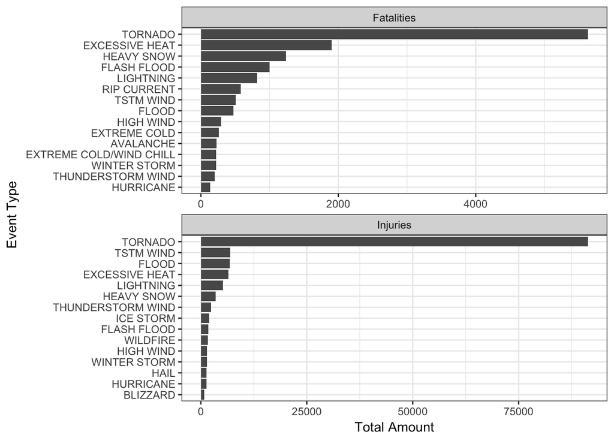

```r
top <- 15
topFatal <-  filter(casualties, type == "Fatalities") %>%
    arrange(desc(amount)) %>%
    head(top)
topInjury <- filter(casualties, type == "Injuries") %>%
    arrange(desc(amount)) %>%
    head(top)
fatalityRange <- filter(casualties,! eventGroup %in% topFatal$eventGroup) %>% select(amount) %>% range()
injuryRange <- filter(casualties,! eventGroup %in% topInjury$eventGroup) %>% select(amount) %>% range()
incommon <- intersect(topFatal$eventGroup, topInjury$eventGroup) %>% length()
# These next four lines allow for the plot to be ordered by highest amount independently
# across the facets
topBoth <- rbind(topInjury, topFatal) %>% arrange(amount, type) %>% as.data.frame()
topBoth$t <- as.numeric(factor(topBoth$type))
topBoth <- plyr::ddply(topBoth, .(type, eventGroup), transform, x=paste(c(rep(' ', t-1), eventGroup), collapse=''))
topBoth$x = factor(topBoth$x, levels=topBoth[order(topBoth$amount), 'x'])
ggplot(data=topBoth, aes(x=x, y=amount)) +
    facet_wrap(~type, scales="free", ncol=1) +
    geom_bar(stat="identity") +
    coord_flip() +
    xlab("Event Type") +
    ylab("Total Amount") +
    theme_bw()
```

## Fiscal Effect of Weather Events

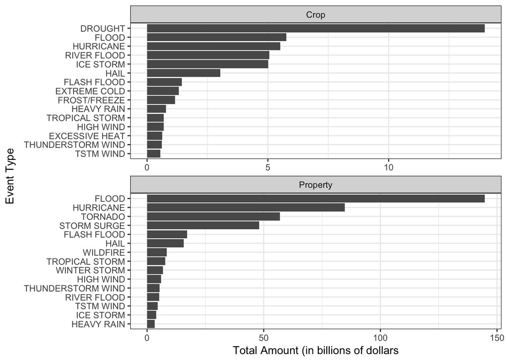

```r
top <- 15
topProp <-  filter(damages, dmg.type == "Property") %>%
    arrange(desc(total.damage)) %>%
    head(top)
topCrop <- filter(damages, dmg.type == "Crop") %>%
    arrange(desc(total.damage)) %>%
    head(top)
propDmgRange <- filter(damages,! eventGroup %in% topProp$eventGroup) %>%
        as.data.frame() %>%
        select(total.damage) %>%
        range()
cropDmgRange <- filter(damages,! eventGroup %in% topCrop$eventGroup) %>%
        as.data.frame() %>%
        select(total.damage) %>%
        range()
incommon.dmg <- intersect(topProp$eventGroup, topCrop$eventGroup) %>% length()
# These next four lines allow for the plot to be ordered by highest amount independently
# across the facets
topBoth <- rbind(topProp, topCrop) %>% arrange(total.damage, dmg.type) %>% as.data.frame()
topBoth$t <- as.numeric(factor(topBoth$dmg.type))
topBoth <- plyr::ddply(topBoth, .(dmg.type, eventGroup), transform, x=paste(c(rep(' ', t-1), eventGroup), collapse=''))
topBoth$x = factor(topBoth$x, levels=topBoth[order(topBoth$total.damage), 'x'])
ggplot(data=topBoth, aes(x=x, y=total.damage)) +
    facet_wrap(~dmg.type, scales="free", ncol=1) +
    geom_bar(stat="identity") +
    coord_flip() +
    xlab("Event Type") +
    ylab("Total Amount (in billions of dollars") +
    theme_bw()
```